[figure not shown]

# Authors

- Adrián Martínez Balea
- Hugo García Souto
- Francisco Manuel Vázquez Fernández

> **Note.** Some parts of the data profiling and preprocessing stages in this notebook—although not the main focus of the project—were inspired by a public Kaggle notebook on the German Credit dataset. In particular, this includes some of the exploratory visualizations and preprocessing ideas that were later adapted to fit the final version of our workflow. The original notebook can be found here: https://www.kaggle.com/code/luuthihuynhnhu/predicting-credit-risk-model-pipeline-763ef1.

## Project requirements

| Software / Library | Package | Version | Purpose |
| --- | --- | --- | --- |
| Python | `python` | 3.11 | Main programming language used in the notebook |
| Package manager | `pip` | latest in environment | Installation of Python packages not installed through conda |
| Numerical computing | `numpy` | latest compatible | Array operations and numerical computations |
| Data manipulation | `pandas` | latest compatible | Data loading, preprocessing, and tabular analysis |
| Scientific computing | `scipy` | latest compatible | Statistical and scientific utilities |
| Machine learning | `scikit-learn` | latest compatible | Classical ML models, preprocessing, metrics, and model selection |
| Visualization | `matplotlib` | latest compatible | Static plots and charts |
| Visualization | `seaborn` | latest compatible | Statistical data visualization |
| Interactive visualization | `plotly` | latest compatible | Interactive plots and visual analysis |
| Notebook environment | `notebook` | latest compatible | Classic Jupyter notebook interface |
| Notebook environment | `jupyterlab` | latest compatible | JupyterLab development environment |
| Jupyter kernel | `ipykernel` | latest compatible | Kernel registration for the project environment |
| Interpretable ML | `imodels` | latest compatible | RuleFit implementation and rule-based interpretation |
| Gradient boosting | `xgboost` | latest compatible | XGBoost classifier used as a predictive baseline |
| Conda environment | `txai-rulefit` | custom | Isolated environment for reproducibility |
| Jupyter kernel name | `Python (txai-rulefit)` | custom | Registered kernel for executing the notebook |

# 0. Introduction

## Context

In credit risk assessment, predictive modelling is not only a performance-driven task but also a decision-making problem with important practical consequences. Financial institutions must identify risky applicants as accurately as possible, while at the same time ensuring that their models remain understandable, auditable, and aligned with regulatory expectations. This creates a natural tension between highly expressive black-box models, which often achieve strong predictive results, and interpretable models, which offer greater transparency but may fail to capture complex relationships in the data.

## Objective

The objective of this notebook is to study this trade-off on the German Credit dataset by combining predictive modelling and interpretability analysis in a single pipeline. First, we explore and preprocess the data to obtain a suitable representation for machine learning. Then, we train and compare several classification models with different levels of complexity. Finally, we use RuleFit both as an interpretable predictive model and as a rule-based surrogate to distill the behaviour of stronger black-box models, allowing us to evaluate how well predictive power can be complemented by transparent and human-readable decision rules.

# 1. Data profiling

This section presents an initial exploratory analysis of the German Credit dataset. The goal is to understand the structure of the data, inspect the main variables, identify missing values and categorical levels, and explore how different customer attributes relate to the target variable. This preliminary profiling step is essential to gain intuition about the problem, detect potentially informative patterns, and guide the preprocessing and modelling decisions developed in the following sections.

```python
#Load the librarys
import pandas as pd #To work with dataset
import numpy as np #Math library
import seaborn as sns #Graph library that use matplot in background
import matplotlib.pyplot as plt #to plot some parameters in seaborn
import warnings
warnings.filterwarnings("ignore")

#Importing the data
df_credit = pd.read_csv("./german_credit_data.csv",index_col=0)

df_credit.head()
```

|  | Age | Sex | Job | Housing | Saving accounts | Checking account | Credit amount | Duration | Purpose | Risk |
| --- | --- | --- | --- | --- | --- | --- | --- | --- | --- | --- |
| 0 | 67 | male | 2 | own | NaN | little | 1169 | 6 | radio/TV | good |
| 1 | 22 | female | 2 | own | little | moderate | 5951 | 48 | radio/TV | bad |
| 2 | 49 | male | 1 | own | little | NaN | 2096 | 12 | education | good |
| 3 | 45 | male | 2 | free | little | little | 7882 | 42 | furniture/equipment | good |
| 4 | 53 | male | 2 | free | little | little | 4870 | 24 | car | bad |

```
--- Dataset Info ---
<class 'pandas.DataFrame'>
RangeIndex: 1000 entries, 0 to 999
Data columns (total 10 columns):
 #   Column            Non-Null Count  Dtype
---  ------            --------------  -----
 0   Age               1000 non-null   int64
 1   Sex               1000 non-null   str
 2   Job               1000 non-null   int64
 3   Housing           1000 non-null   str
 4   Saving accounts   817 non-null    str
 5   Checking account  606 non-null    str
 6   Credit amount     1000 non-null   int64
 7   Duration          1000 non-null   int64
 8   Purpose           1000 non-null   str
 9   Risk              1000 non-null   str
dtypes: int64(4), str(6)
memory usage: 78.3 KB
```

```
None
```

|  | Age | Sex | Job | Housing | Saving accounts | Checking account | Credit amount | Duration | Purpose | Risk |
| --- | --- | --- | --- | --- | --- | --- | --- | --- | --- | --- |
| 0 | 67 | male | 2 | own | NaN | little | 1169 | 6 | radio/TV | good |
| 1 | 22 | female | 2 | own | little | moderate | 5951 | 48 | radio/TV | bad |
| 2 | 49 | male | 1 | own | little | NaN | 2096 | 12 | education | good |
| 3 | 45 | male | 2 | free | little | little | 7882 | 42 | furniture/equipment | good |
| 4 | 53 | male | 2 | free | little | little | 4870 | 24 | car | bad |

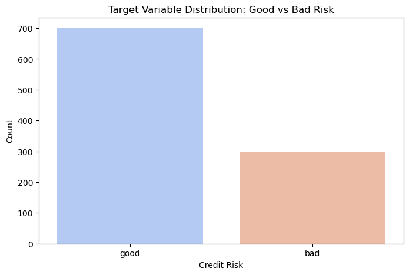

```python
print("--- Dataset Info ---")
display(df_credit.info())
display(df_credit.head())

plt.figure(figsize=(8, 5))
sns.countplot(data=df_credit, x='Risk', palette='coolwarm')
plt.title('Target Variable Distribution: Good vs Bad Risk')
plt.ylabel('Count')
plt.xlabel('Credit Risk')
plt.show()
```

```
Description of Distribuition Saving accounts by Risk:
Risk             bad  good
Saving accounts
little           217   386
moderate          34    69
quite rich        11    52
rich               6    42
```

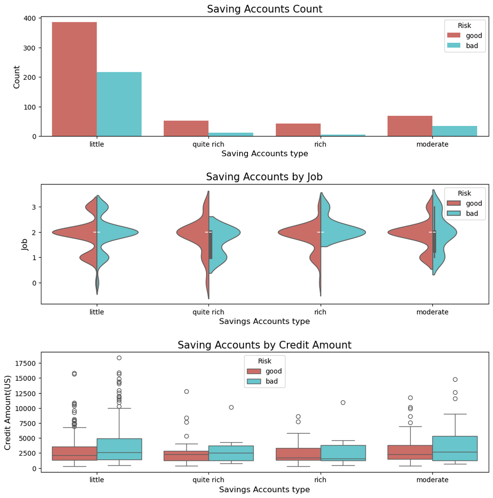

```python
# Show a contingency table of Saving accounts vs Risk
print("Description of Distribuition Saving accounts by Risk:  ")
print(pd.crosstab(df_credit["Saving accounts"], df_credit.Risk))

# Create a figure with three subplots to analyze Saving accounts from different perspectives
fig, ax = plt.subplots(3, 1, figsize=(12, 12))

# Plot the count of each Saving accounts category, split by Risk
g = sns.countplot(
    x="Saving accounts",
    data=df_credit,
    palette="hls",
    ax=ax[0],
    hue="Risk"
)
g.set_title("Saving Accounts Count", fontsize=15)
g.set_xlabel("Saving Accounts type", fontsize=12)
g.set_ylabel("Count", fontsize=12)

# Compare the distribution of Job across Saving accounts categories and Risk groups
g1 = sns.violinplot(
    x="Saving accounts",
    y="Job",
    data=df_credit,
    palette="hls",
    hue="Risk",
    ax=ax[1],
    split=True
)
g1.set_title("Saving Accounts by Job", fontsize=15)
g1.set_xlabel("Savings Accounts type", fontsize=12)
g1.set_ylabel("Job", fontsize=12)

# Compare Credit amount across Saving accounts categories and Risk groups
g2 = sns.boxplot(
    x="Saving accounts",
    y="Credit amount",
    data=df_credit,
    ax=ax[2],
    hue="Risk",
    palette="hls"
)
g2.set_title("Saving Accounts by Credit Amount", fontsize=15)
g2.set_xlabel("Savings Accounts type", fontsize=12)
g2.set_ylabel("Credit Amount(US)", fontsize=12)

# Adjust spacing between plots and display the figure
plt.subplots_adjust(hspace=0.4, top=0.9)
plt.show()
```

```python
import plotly.graph_objs as go
import plotly.offline as py

py.init_notebook_mode(connected=True)

#First plot
trace0 = go.Bar(
    x = df_credit[df_credit["Risk"]== 'good']["Checking account"].value_counts().index.values,
    y = df_credit[df_credit["Risk"]== 'good']["Checking account"].value_counts().values,
    name='Good credit Distribuition'

)

#Second plot
trace1 = go.Bar(
    x = df_credit[df_credit["Risk"]== 'bad']["Checking account"].value_counts().index.values,
    y = df_credit[df_credit["Risk"]== 'bad']["Checking account"].value_counts().values,
    name="Bad Credit Distribuition"
)

data = [trace0, trace1]

layout = go.Layout(
    title='Checking accounts Distribuition',
    xaxis=dict(title='Checking accounts name'),
    yaxis=dict(title='Count'),
    barmode='group'
)


fig = go.Figure(data=data, layout=layout)

py.iplot(fig, filename = 'Age-ba', validate = False)
```

[interactive chart not shown]

```python
print(pd.crosstab(df_credit.Sex, df_credit.Job))
```

```
Job      0    1    2    3
Sex
female  12   64  197   37
male    10  136  433  111
```

```python
print(pd.crosstab(df_credit["Checking account"],df_credit.Sex))
```

```
Sex               female  male
Checking account
little                88   186
moderate              86   183
rich                  20    43
```

```python
date_int = ["Purpose", 'Sex']
cm = sns.light_palette("green", as_cmap=True)
pd.crosstab(df_credit[date_int[0]], df_credit[date_int[1]]).style.background_gradient(cmap = cm)
```

| Sex Purpose | female | male |
| --- | --- | --- |
| business | 19 | 78 |
| car | 94 | 243 |
| domestic appliances | 6 | 6 |
| education | 24 | 35 |
| furniture/equipment | 74 | 107 |
| radio/TV | 85 | 195 |
| repairs | 5 | 17 |
| vacation/others | 3 | 9 |

```python
date_int = ["Purpose", 'Sex']
cm = sns.light_palette("green", as_cmap=True)
pd.crosstab(df_credit[date_int[0]], df_credit[date_int[1]]).style.background_gradient(cmap = cm)
```

| Sex Purpose | female | male |
| --- | --- | --- |
| business | 19 | 78 |
| car | 94 | 243 |
| domestic appliances | 6 | 6 |
| education | 24 | 35 |
| furniture/equipment | 74 | 107 |
| radio/TV | 85 | 195 |
| repairs | 5 | 17 |
| vacation/others | 3 | 9 |

```python
print("Purpose : ",df_credit.Purpose.unique())
print("Sex : ",df_credit.Sex.unique())
print("Housing : ",df_credit.Housing.unique())
print("Saving accounts : ",df_credit['Saving accounts'].unique())
print("Risk : ",df_credit['Risk'].unique())
print("Checking account : ",df_credit['Checking account'].unique())
```

```
Purpose :  <StringArray>
[           'radio/TV',           'education', 'furniture/equipment',
                 'car',            'business', 'domestic appliances',
             'repairs',     'vacation/others']
Length: 8, dtype: str
Sex :  <StringArray>
['male', 'female']
Length: 2, dtype: str
Housing :  <StringArray>
['own', 'free', 'rent']
Length: 3, dtype: str
Saving accounts :  <StringArray>
[nan, 'little', 'quite rich', 'rich', 'moderate']
Length: 5, dtype: str
Risk :  <StringArray>
['good', 'bad']
Length: 2, dtype: str
Checking account :  <StringArray>
['little', 'moderate', nan, 'rich']
Length: 4, dtype: str
```

# 2. Preprocessing

In this section, the dataset is transformed into a machine-learning-ready format. Missing values are handled, categorical variables are encoded into numerical representations, redundant columns are removed, and selected variables are transformed to improve their statistical behaviour. The purpose of this preprocessing stage is to obtain a clean and consistent feature space that can be reliably used by the predictive models while preserving as much useful information as possible for both classification and later interpretability analyses.

```python
# Creating a categorical variable to handle with the Age variable
interval = (18, 25, 35, 60, 120)

cats = ['Student', 'Young', 'Adult', 'Senior']
df_credit["Age_cat"] = pd.cut(df_credit.Age, interval, labels=cats)
```

```python
# Fill missing values in Saving accounts and Checking account with a new category
df_credit['Saving accounts'] = df_credit['Saving accounts'].fillna('no_inf')
df_credit['Checking account'] = df_credit['Checking account'].fillna('no_inf')

# Convert Purpose into dummy variables and merge them into the dataframe
df_credit = df_credit.merge(
    pd.get_dummies(df_credit.Purpose, drop_first=True, prefix='Purpose'),
    left_index=True,
    right_index=True
)

# Convert Sex into dummy variables and merge them into the dataframe
df_credit = df_credit.merge(
    pd.get_dummies(df_credit.Sex, drop_first=True, prefix='Sex'),
    left_index=True,
    right_index=True
)

# Convert Housing into dummy variables and merge them into the dataframe
df_credit = df_credit.merge(
    pd.get_dummies(df_credit.Housing, drop_first=True, prefix='Housing'),
    left_index=True,
    right_index=True
)

# Convert Saving accounts into dummy variables and merge them into the dataframe
df_credit = df_credit.merge(
    pd.get_dummies(df_credit["Saving accounts"], drop_first=True, prefix='Savings'),
    left_index=True,
    right_index=True
)

# Convert Risk into dummy variables and merge them into the dataframe
df_credit = df_credit.merge(
    pd.get_dummies(df_credit.Risk, prefix='Risk'),
    left_index=True,
    right_index=True
)

# Convert Checking account into dummy variables and merge them into the dataframe
df_credit = df_credit.merge(
    pd.get_dummies(df_credit["Checking account"], drop_first=True, prefix='Check'),
    left_index=True,
    right_index=True
)

# Convert the age category variable into dummy variables and merge them into the dataframe
df_credit = df_credit.merge(
    pd.get_dummies(df_credit["Age_cat"], drop_first=True, prefix='Age_cat'),
    left_index=True,
    right_index=True
)
```

```python
# Remove the original categorical columns after one-hot encoding
del df_credit["Saving accounts"]
del df_credit["Checking account"]
del df_credit["Purpose"]
del df_credit["Sex"]
del df_credit["Housing"]
del df_credit["Age_cat"]

# Remove the original target column and keep only the binary target of interest
del df_credit["Risk"]
del df_credit["Risk_good"]
```

```python
# Apply a log transformation to reduce the skewness of Credit amount
df_credit['Credit amount'] = np.log(df_credit['Credit amount'])
```

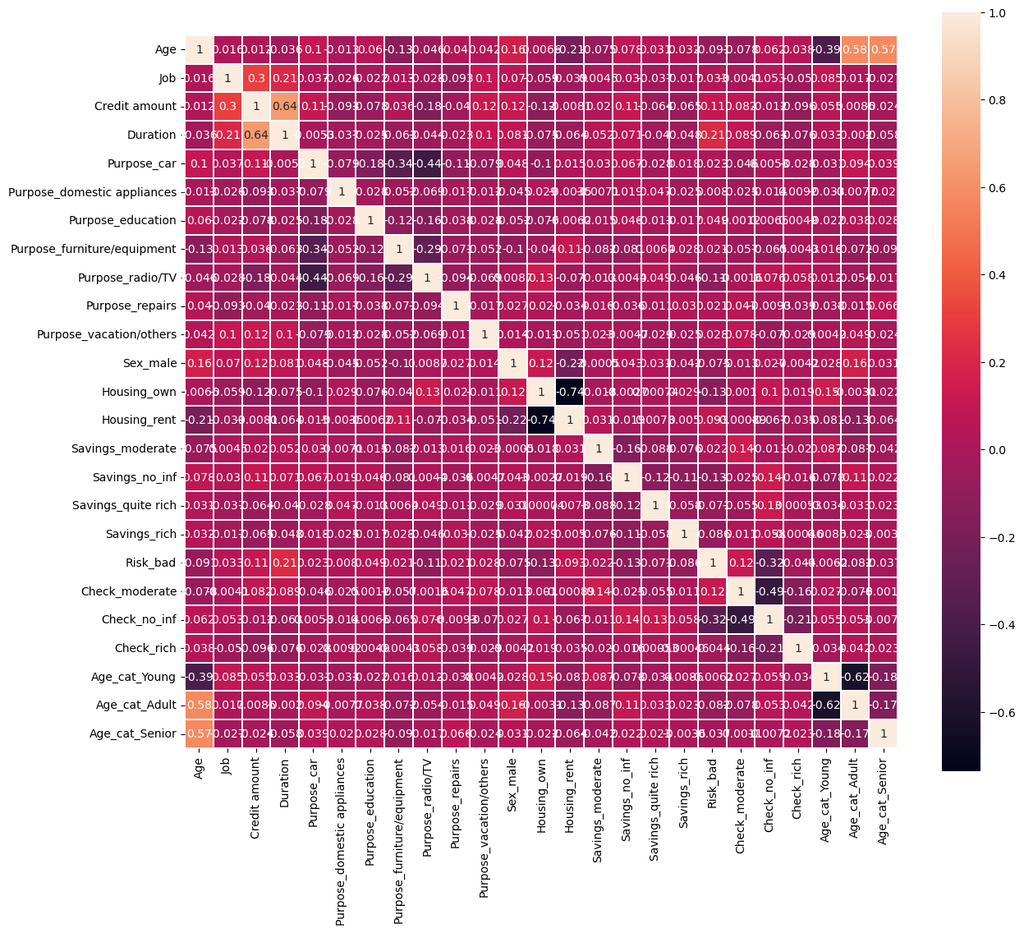

```python
# Create a large figure to display the correlation matrix clearly
plt.figure(figsize=(14, 12))

# Plot the correlation heatmap for all numerical features in the dataframe
sns.heatmap(
    df_credit.astype(float).corr(),
    linewidths=0.1,
    vmax=1.0,
    square=True,
    linecolor='white',
    annot=True
)

# Display the plot
plt.show()
```

```python
from sklearn.model_selection import train_test_split

# Creating the X and y variables
X = df_credit.drop('Risk_bad', axis=1).values
y = df_credit["Risk_bad"].values

# Spliting X and y into train and test version
X_train, X_test, y_train, y_test = train_test_split(X, y, test_size = 0.25, random_state=42)
```

```python
print(df_credit.columns.tolist())
```

[output not shown]

```python
X_train.shape
```

```
(750, 24)
```

```python
y_train.shape
```

```
(750,)
```

# 3. Models

This section focuses on the predictive modelling stage. We begin with a broad comparison of different classification algorithms in order to obtain an initial view of their behaviour on the credit risk task. Then, we examine selected models in greater detail, including hyperparameter tuning and performance evaluation on the test set. The aim is to identify strong candidate models for the problem while also establishing a reference point for the interpretability analyses that will be developed later through RuleFit-based rule extraction and distillation.

```python
from sklearn.model_selection import cross_val_score, StratifiedKFold # To split the data
from sklearn.metrics import accuracy_score, confusion_matrix, classification_report, fbeta_score # To evaluate our model

from sklearn.model_selection import GridSearchCV

# Algorithmns models to be compared
from sklearn.ensemble import RandomForestClassifier
from sklearn.linear_model import LogisticRegression
from sklearn.tree import DecisionTreeClassifier
from sklearn.neighbors import KNeighborsClassifier
from sklearn.ensemble import RandomForestClassifier
from sklearn.discriminant_analysis import LinearDiscriminantAnalysis
from sklearn.naive_bayes import GaussianNB
from sklearn.svm import SVC
from xgboost import XGBClassifier
```

```
LR: 0.490015 (0.080801)
LDA: 0.480855 (0.070994)
KNN: 0.304825 (0.151925)
CART: 0.457925 (0.057503)
NB: 0.537979 (0.065546)
RF: 0.445381 (0.083741)
SVM: 0.226768 (0.130845)
XGB: 0.546022 (0.076033)
```

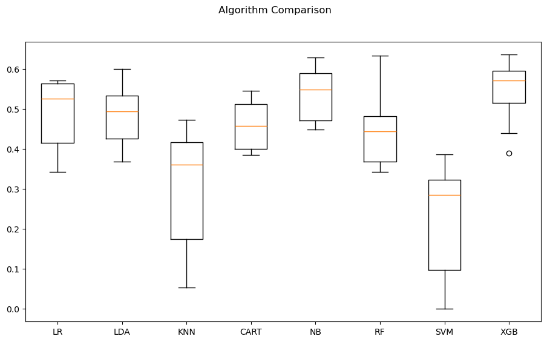

```python
# Set the random seed for reproducibility
seed = 7

# Prepare the candidate classification models
models = []
models.append(('LR', LogisticRegression()))
models.append(('LDA', LinearDiscriminantAnalysis()))
models.append(('KNN', KNeighborsClassifier()))
models.append(('CART', DecisionTreeClassifier()))
models.append(('NB', GaussianNB()))
models.append(('RF', RandomForestClassifier()))
models.append(('SVM', SVC(gamma='auto')))
models.append(('XGB', XGBClassifier()))

# Evaluate each model with stratified 10-fold cross-validation using f1
results = []
names = []
scoring = 'f1'

for name, model in models:
    skfold = StratifiedKFold(n_splits=10, shuffle=True, random_state=seed)
    cv_results = cross_val_score(model, X_train, y_train, cv=skfold, scoring=scoring)
    results.append(cv_results)
    names.append(name)
    msg = "%s: %f (%f)" % (name, cv_results.mean(), cv_results.std())
    print(msg)

# Plot a boxplot to compare the performance distribution of all models
fig = plt.figure(figsize=(11, 6))
fig.suptitle('Algorithm Comparison')
ax = fig.add_subplot(111)
plt.boxplot(results)
ax.set_xticklabels(names)
plt.show()
```

### Model 1 (RF)

- Using Random Forest to predictict the credit score
- Some of Validation Parameters

```python
# Seting the Hyper Parameters
param_grid = {"max_depth": [3,5, 7, 10,None],
              "n_estimators":[3,5,10,25,50,150],
              "max_features": [4,7,15,20]}

# Creating the classifier
model = RandomForestClassifier(random_state=2)

grid_search = GridSearchCV(model, param_grid=param_grid, cv=5, scoring='f1', verbose=0)
grid_search.fit(X_train, y_train)
```

```
GridSearchCV(cv=5, estimator=RandomForestClassifier(random_state=2),
             param_grid={'max_depth': [3, 5, 7, 10, None],
                         'max_features': [4, 7, 15, 20],
                         'n_estimators': [3, 5, 10, 25, 50, 150]},
             scoring='f1')
```

```python
print(grid_search.best_score_)
print(grid_search.best_params_)
```

```
0.5164149930529242
{'max_depth': None, 'max_features': 20, 'n_estimators': 3}
```

```python
rf = RandomForestClassifier(max_depth=None, max_features=20, n_estimators=3, random_state=2)

#trainning with the best params
rf.fit(X_train, y_train)
```

```
RandomForestClassifier(max_features=20, n_estimators=3, random_state=2)
```

```python
#Testing the model
#Predicting using our  model
y_pred = rf.predict(X_test)

# Check the results
print(accuracy_score(y_test,y_pred))
print("\n")
print(confusion_matrix(y_test, y_pred))
print("\n")
print(fbeta_score(y_test, y_pred, beta=2))
```

```
0.712


[[146  32]
 [ 40  32]]


0.45454545454545453
```

### Model 2 (GNB)

```python
from sklearn.metrics import roc_curve
```

```python
# Define the hyperparameter grid for GaussianNB
param_gnb = {
    'var_smoothing': np.logspace(0, -12, num=50)
}

# Create the Gaussian Naive Bayes classifier
gnb = GaussianNB()

# Perform grid search using f1 as the scoring metric
grid_gnb = GridSearchCV(
    estimator=gnb,
    param_grid=param_gnb,
    cv=5,
    scoring='f1'
)

# Fit the search on the training data
grid_gnb.fit(X_train, y_train)
```

```
GridSearchCV(cv=5, estimator=GaussianNB(),
             param_grid={'var_smoothing': array([1.00000000e+00, 5.68986603e-01, 3.23745754e-01, 1.84206997e-01,
       1.04811313e-01, 5.96362332e-02, 3.39322177e-02, 1.93069773e-02,
       1.09854114e-02, 6.25055193e-03, 3.55648031e-03, 2.02358965e-03,
       1.15139540e-03, 6.55128557e-04, 3.72759372e-04, 2.12095089e-04,
       1.20679264e-04, 6.86648845e-05, 3.90...
       1.32571137e-06, 7.54312006e-07, 4.29193426e-07, 2.44205309e-07,
       1.38949549e-07, 7.90604321e-08, 4.49843267e-08, 2.55954792e-08,
       1.45634848e-08, 8.28642773e-09, 4.71486636e-09, 2.68269580e-09,
       1.52641797e-09, 8.68511374e-10, 4.94171336e-10, 2.81176870e-10,
       1.59985872e-10, 9.10298178e-11, 5.17947468e-11, 2.94705170e-11,
       1.67683294e-11, 9.54095476e-12, 5.42867544e-12, 3.08884360e-12,
       1.75751062e-12, 1.00000000e-12])},
             scoring='f1')
```

```python
# Show the best cross-validation score and parameter
print(grid_gnb.best_score_)
print(grid_gnb.best_params_)
```

```
0.5626796827464178
{'var_smoothing': np.float64(1.2648552168552958e-05)}
```

```python
# Predict on the test set with the best model
y_pred_gnb = grid_gnb.predict(X_test)
```

```python
# Evaluate the final model
print(accuracy_score(y_test, y_pred_gnb))
print("\n")
print(confusion_matrix(y_test, y_pred_gnb))
print("\n")
print(fbeta_score(y_test, y_pred_gnb, beta=2))
```

```
0.648


[[124  54]
 [ 34  38]]


0.5
```

#### Let's verify the ROC curve

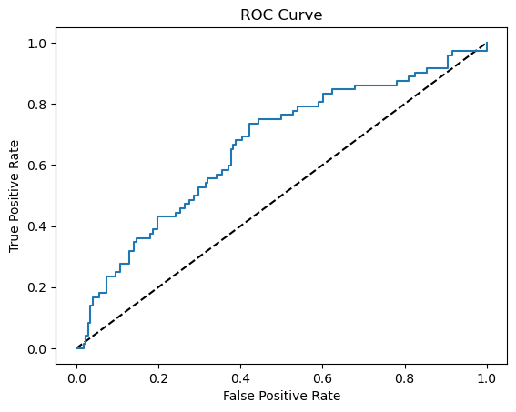

```python
# Predicting proba
y_pred_prob = grid_gnb.predict_proba(X_test)[:,1]

# Generate ROC curve values: fpr, tpr, thresholds
fpr, tpr, thresholds = roc_curve(y_test, y_pred_prob)

# Plot ROC curve
plt.plot([0, 1], [0, 1], 'k--')
plt.plot(fpr, tpr)
plt.xlabel('False Positive Rate')
plt.ylabel('True Positive Rate')
plt.title('ROC Curve')
plt.show()
```

### Model 3 (PCA + SelectKBest + GaussianNB)

```python
from sklearn.model_selection import cross_val_score
from sklearn.pipeline import Pipeline
from sklearn.pipeline import FeatureUnion
from sklearn.decomposition import PCA
from sklearn.feature_selection import SelectKBest
```

```python
features = []
features.append(('pca', PCA(n_components=2)))
features.append(('select_best', SelectKBest(k=6)))
feature_union = FeatureUnion(features)

# create pipeline
estimators = []
estimators.append(('feature_union', feature_union))
estimators.append(('logistic', GaussianNB()))
model = Pipeline(estimators)

# evaluate pipeline
seed = 7
kfold = StratifiedKFold(n_splits=10, shuffle=True, random_state=seed)
results = cross_val_score(model, X_train, y_train, cv=kfold)
print(results.mean())
```

```
0.7013333333333333
```

```python
model.fit(X_train, y_train)
y_pred = model.predict(X_test)

print(accuracy_score(y_test,y_pred))
print("\n")
print(confusion_matrix(y_test, y_pred))
print("\n")
print(fbeta_score(y_test, y_pred, beta=2))
```

```
0.72


[[149  29]
 [ 41  31]]


0.4454022988505747
```

### Model 4 (XGB)

```python
# Seting the Hyper Parameters
xgb_grid = {
 'max_depth':[3,5,6,10],
 'min_child_weight':[3,5,10],
 'gamma':[0.0, 0.1, 0.2, 0.3, 0.4],
 'subsample':[i/100.0 for i in range(75,90,5)],
 'colsample_bytree':[i/100.0 for i in range(75,90,5)]
}

# Creating the classifier
model_xg = XGBClassifier(random_state=2)

grid_search = GridSearchCV(model_xg, param_grid=xgb_grid, cv=5, scoring='f1')
grid_search.fit(X_train, y_train)
```

```
GridSearchCV(cv=5,
             estimator=XGBClassifier(base_score=None, booster=None,
                                     callbacks=None, colsample_bylevel=None,
                                     colsample_bynode=None,
                                     colsample_bytree=None, device=None,
                                     early_stopping_rounds=None,
                                     enable_categorical=False, eval_metric=None,
                                     feature_types=None, feature_weights=None,
                                     gamma=None, grow_policy=None,
                                     importance_type=None,
                                     interaction_constraints=Non...
                                     max_delta_step=None, max_depth=None,
                                     max_leaves=None, min_child_weight=None,
                                     missing=nan, monotone_constraints=None,
                                     multi_strategy=None, n_estimators=None,
                                     n_jobs=None, num_parallel_tree=None, ...),
             param_grid={'colsample_bytree': [0.75, 0.8, 0.85],
                         'gamma': [0.0, 0.1, 0.2, 0.3, 0.4],
                         'max_depth': [3, 5, 6, 10],
                         'min_child_weight': [3, 5, 10],
                         'subsample': [0.75, 0.8, 0.85]},
             scoring='f1')
```

```python
# Show the best cross-validation score and parameter
print(grid_search.best_score_)
print(grid_search.best_params_)
```

```
0.5481838665397973
{'colsample_bytree': 0.85, 'gamma': 0.2, 'max_depth': 3, 'min_child_weight': 3, 'subsample': 0.8}
```

```python
y_pred = grid_search.predict(X_test)
```

```python
# Verificaar os resultados obtidos
print(accuracy_score(y_test,y_pred))
print("\n")
print(confusion_matrix(y_test, y_pred))
```

```
0.748


[[153  25]
 [ 38  34]]
```

## 4. RuleFit-based interpretation

After evaluating several predictive models, this section introduces RuleFit as an interpretable rule-based approach for credit risk classification. Unlike purely black-box methods, RuleFit combines sparse linear modelling with decision rules extracted from tree structures, making it possible to inspect the patterns that drive predictions. The purpose of this section is to assess RuleFit not only as a classifier, but also as an interpretation tool capable of revealing the most influential decision rules and providing a global view of the factors associated with bad credit risk.

```python
# Import RuleFit and evaluation metrics
from imodels.rule_set.rule_fit import RuleFitClassifier
from sklearn.metrics import accuracy_score, recall_score, precision_score, f1_score, roc_auc_score, confusion_matrix, classification_report
import pandas as pd
import numpy as np
import matplotlib.pyplot as plt
import seaborn as sns

# Retrieve feature names so extracted rules are readable
feature_names = df_credit.drop(columns=['Risk_bad']).columns.tolist()
```

```python
# Set the random seed for reproducibility
seed = 7

# Initialize the RuleFit model
rulefit_model = RuleFitClassifier(
    max_rules=50,
    tree_size=3,
    random_state=seed
)

# Train the RuleFit model on the real target labels
print("Training RuleFit model...")
rulefit_model.fit(X_train, y_train, feature_names=feature_names)
```

```
Training RuleFit model...
```

```
> ------------------------------
> RuleFit:
> 	Predictions are made by summing the coefficients of each rule
> ------------------------------
                                                                                     rule  coef
                                                                                      Job  0.04
                                                                            Credit amount -0.03
                                                                        Purpose_education  0.16
                                                                         Purpose_radio/TV -0.16
                                                                             Savings_rich -0.09
                                                                               Check_rich -0.04
                                                                            Age_cat_Young -0.14
                                                                            Age_cat_Adult  0.13
                                                                 Credit amount <= 9.37483 -0.06
                                             Credit amount <= 8.9568 and Duration <= 45.0 -0.41
                                                  Age > 24.5 and Credit amount <= 9.32279  0.02
                                            Credit amount <= 8.96094 and Duration <= 31.5 -0.49
                                                          Job <= 2.5 and Duration <= 33.0 -0.12
                                              Savings_rich <= 0.5 and Check_no_inf <= 0.5  0.47
                                           Housing_own > 0.5 and Credit amount <= 8.35019 -0.44
                                                Check_no_inf <= 0.5 and Check_rich <= 0.5  0.27
                                                  Check_no_inf <= 0.5 and Duration > 11.5  0.01
                             Check_no_inf <= 0.5 and Duration <= 33.0 and Duration > 11.5  0.13
                                                  Check_no_inf <= 0.5 and Duration > 13.0  0.08
                      Check_no_inf <= 0.5 and Credit amount > 7.2391 and Duration <= 33.0 -0.08
                                          Check_no_inf > 0.5 and Credit amount <= 8.27219 -0.43
                                                  Age > 35.5 and Credit amount <= 8.26769 -0.84
                                                    Age <= 28.5 and Savings_no_inf <= 0.5  0.12
                                                                   Purpose_radio/TV > 0.5 -0.00
                                         Check_no_inf <= 0.5 and Credit amount <= 7.68789  0.50
                                          Check_no_inf <= 0.5 and Credit amount > 8.01433 -0.13
                        Savings_no_inf <= 0.5 and Check_no_inf <= 0.5 and Duration > 22.5  0.54
                                          Housing_own <= 0.5 and Credit amount <= 8.36077  0.16
                                                   Age > 28.5 and Credit amount > 8.34032 -0.21
 Age > 25.5 and Check_moderate > 0.5 and Check_no_inf <= 0.5 and Credit amount <= 8.92152 -0.52
                              Age <= 35.5 and Sex_male <= 0.5 and Purpose_radio/TV <= 0.5  0.49
                                          Check_no_inf <= 0.5 and Credit amount <= 7.2391  0.65
                                                   Check_no_inf > 0.5 and Duration > 22.5 -0.52
                                Age <= 29.5 and Savings_no_inf <= 0.5 and Duration > 22.5  0.42
          Age <= 26.5 and Check_no_inf <= 0.5 and Duration <= 25.5 and Purpose_car <= 0.5 -0.74
                                                 Savings_no_inf > 0.5 and Duration > 22.5 -0.36
                                                                          Duration <= 8.5 -0.29
                                                                          Duration <= 8.0 -0.45
                                                                          Duration > 40.5 -0.01
                                                 Check_no_inf <= 0.5 and Check_rich > 0.5 -0.50
Age <= 25.5 and Check_moderate > 0.5 and Check_no_inf <= 0.5 and Credit amount <= 8.92152  0.07
                                                     Age <= 28.5 and Savings_no_inf > 0.5 -0.03
                                           Housing_own <= 0.5 and Credit amount > 8.94533  0.04
                                              Credit amount <= 8.9568 and Duration > 45.0  0.32
                                               Savings_rich > 0.5 and Check_no_inf <= 0.5 -0.10
                             Age <= 34.5 and Check_rich > 0.5 and Purpose_radio/TV <= 0.5 -0.07
```

```python
# Generate predictions and probabilities on the test set
y_pred_rulefit = rulefit_model.predict(X_test)
y_pred_rulefit_proba = rulefit_model.predict_proba(X_test)[:, 1]

# Compute core evaluation metrics
accuracy = accuracy_score(y_test, y_pred_rulefit)
precision = precision_score(y_test, y_pred_rulefit)
recall = recall_score(y_test, y_pred_rulefit)
f1 = f1_score(y_test, y_pred_rulefit)
roc_auc = roc_auc_score(y_test, y_pred_rulefit_proba)

print("RuleFit performance on the test set:")
print(f"Accuracy : {accuracy:.4f}")
print(f"Precision: {precision:.4f}")
print(f"Recall   : {recall:.4f}")
print(f"F1-score : {f1:.4f}")
print(f"ROC AUC  : {roc_auc:.4f}")

print("\nConfusion Matrix:")
print(confusion_matrix(y_test, y_pred_rulefit))

print("\nClassification Report:")
print(classification_report(y_test, y_pred_rulefit))
```

```
RuleFit performance on the test set:
Accuracy : 0.7400
Precision: 0.6522
Recall   : 0.2083
F1-score : 0.3158
ROC AUC  : 0.7619

Confusion Matrix:
[[170   8]
 [ 57  15]]

Classification Report:
              precision    recall  f1-score   support

       False       0.75      0.96      0.84       178
        True       0.65      0.21      0.32        72

    accuracy                           0.74       250
   macro avg       0.70      0.58      0.58       250
weighted avg       0.72      0.74      0.69       250
```

```python
# Extract the internal table of rules and linear terms
rules_df = rulefit_model._get_rules()

# Keep only actual rule-based terms
extracted_rules = rules_df[rules_df["type"] == "rule"].copy()

# Rank rules by absolute coefficient magnitude
extracted_rules["importance"] = extracted_rules["coef"].abs()
top_rules = extracted_rules.sort_values(by="importance", ascending=False)

# Display the most important rules
top_rules[["rule", "coef", "support", "importance"]].head(10)
```

|  | rule | coef | support | importance |
| --- | --- | --- | --- | --- |
| 30 | Age > 35.5 and Credit amount <= 8.26769 | -0.839793 | 0.292000 | 0.839793 |
| 44 | Age <= 26.5 and Check_no_inf <= 0.5 and Duration <= 25.5 and Purpose_car <= 0.5 | -0.743200 | 0.098667 | 0.743200 |
| 56 | Check_no_inf <= 0.5 and Credit amount <= 7.2391 | 0.654063 | 0.166667 | 0.654063 |
| 54 | Savings_no_inf <= 0.5 and Check_no_inf <= 0.5 and Duration > 22.5 | 0.540565 | 0.217333 | 0.540565 |
| 36 | Check_no_inf > 0.5 and Duration > 22.5 | -0.517121 | 0.166667 | 0.517121 |
| 29 | Age > 25.5 and Check_moderate > 0.5 and Check_no_inf <= 0.5 and Credit amount <= 8.92152 | -0.515670 | 0.177333 | 0.515670 |
| 43 | Check_no_inf <= 0.5 and Credit amount <= 7.68789 | 0.504673 | 0.276000 | 0.504673 |
| 26 | Check_no_inf <= 0.5 and Check_rich > 0.5 | -0.498612 | 0.060000 | 0.498612 |
| 57 | Age <= 35.5 and Sex_male <= 0.5 and Purpose_radio/TV <= 0.5 | 0.491838 | 0.166667 | 0.491838 |
| 38 | Credit amount <= 8.96094 and Duration <= 31.5 | -0.488972 | 0.793333 | 0.488972 |

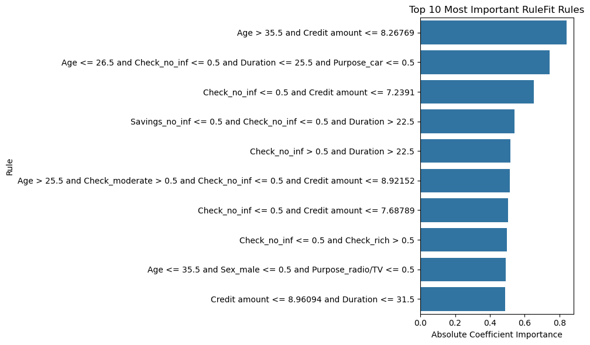

```python
# Select the top 10 most important rules
top10_rules = top_rules.head(10).copy()

# Create a readable label for plotting
top10_rules["rule_label"] = top10_rules["rule"].astype(str)

plt.figure(figsize=(10, 6))
sns.barplot(
    data=top10_rules,
    y="rule_label",
    x="importance"
)
plt.title("Top 10 Most Important RuleFit Rules")
plt.xlabel("Absolute Coefficient Importance")
plt.ylabel("Rule")
plt.tight_layout()
plt.show()
```

```python
# Compute a simple global feature importance based on rule usage
feature_importance = {}

for _, row in extracted_rules.iterrows():
    rule = str(row["rule"])
    importance = abs(row["coef"])
    for feature in feature_names:
        if feature in rule:
            feature_importance[feature] = feature_importance.get(feature, 0) + importance

feature_importance_df = pd.DataFrame(
    feature_importance.items(),
    columns=["feature", "importance"]
).sort_values(by="importance", ascending=False)

feature_importance_df.head(10)
```

|  | feature | importance |
| --- | --- | --- |
| 4 | Check_no_inf | 5.733380 |
| 6 | Credit amount | 5.370958 |
| 5 | Duration | 4.962220 |
| 0 | Age | 3.527391 |
| 8 | Savings_no_inf | 1.468957 |
| 2 | Check_rich | 0.835934 |
| 11 | Purpose_car | 0.743200 |
| 9 | Housing_own | 0.646724 |
| 7 | Check_moderate | 0.589227 |
| 3 | Savings_rich | 0.565926 |

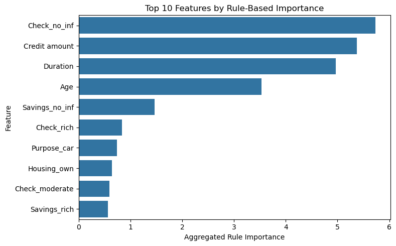

```python
# Plot the top 10 most important features according to the extracted rules
top10_features = feature_importance_df.head(10)

plt.figure(figsize=(8, 5))
sns.barplot(
    data=top10_features,
    y="feature",
    x="importance"
)
plt.title("Top 10 Features by Rule-Based Importance")
plt.xlabel("Aggregated Rule Importance")
plt.ylabel("Feature")
plt.tight_layout()
plt.show()
```

# 5. Rule distillation from black-box models

```python
# Import the models and utilities needed for rule distillation
from imodels.rule_set.rule_fit import RuleFitClassifier
from sklearn.metrics import accuracy_score, recall_score, precision_score, f1_score
from sklearn.pipeline import Pipeline, FeatureUnion
from sklearn.decomposition import PCA
from sklearn.feature_selection import SelectKBest, f_classif
from sklearn.naive_bayes import GaussianNB
from sklearn.ensemble import RandomForestClassifier
from xgboost import XGBClassifier
import pandas as pd
import numpy as np

# Recover readable feature names for RuleFit
if hasattr(X_train, "columns"):
    feature_names = X_train.columns.tolist()
else:
    feature_names = df_credit.drop(columns=["Risk_bad"]).columns.tolist()

# Convert train/test splits to numpy arrays if needed
X_train_array = X_train.values if hasattr(X_train, "values") else X_train
X_test_array = X_test.values if hasattr(X_test, "values") else X_test


# Define a helper function to distill a teacher model with RuleFit
def distill_with_rulefit(teacher_model, teacher_name, X_train_raw, X_test_raw, y_train, y_test,
                         feature_names, seed=7, max_rules=50, tree_size=3):
    # Fit the teacher model on the real labels
    teacher_model.fit(X_train_raw, y_train)

    # Generate teacher predictions on train and test
    y_train_teacher = teacher_model.predict(X_train_raw)
    y_test_teacher = teacher_model.predict(X_test_raw)

    # Train RuleFit to imitate the teacher predictions
    surrogate = RuleFitClassifier(
        max_rules=max_rules,
        tree_size=tree_size,
        random_state=seed
    )
    surrogate.fit(X_train_array, y_train_teacher, feature_names=feature_names)

    # Evaluate the surrogate on the teacher outputs and on the true labels
    y_test_surrogate = surrogate.predict(X_test_array)

    fidelity = accuracy_score(y_test_teacher, y_test_surrogate)
    teacher_accuracy = accuracy_score(y_test, y_test_teacher)
    surrogate_accuracy = accuracy_score(y_test, y_test_surrogate)
    surrogate_recall = recall_score(y_test, y_test_surrogate)
    surrogate_precision = precision_score(y_test, y_test_surrogate)
    surrogate_f1 = f1_score(y_test, y_test_surrogate)

    # Extract and rank the surrogate rules
    rules_df = surrogate._get_rules()
    extracted_rules = rules_df[(rules_df["type"] == "rule") & (rules_df["coef"] != 0)].copy()
    extracted_rules["importance"] = extracted_rules["coef"].abs()
    top_rules = extracted_rules.sort_values(by="importance", ascending=False)

    # Store summary metrics
    summary = {
        "teacher": teacher_name,
        "teacher_accuracy": teacher_accuracy,
        "surrogate_accuracy": surrogate_accuracy,
        "fidelity": fidelity,
        "surrogate_recall": surrogate_recall,
        "surrogate_precision": surrogate_precision,
        "surrogate_f1": surrogate_f1,
        "n_rules": extracted_rules.shape[0]
    }

    return summary, surrogate, top_rules
```

```python
# Set the random seed for reproducibility
seed = 7

# Define the four teacher models from the previous section
teacher_models = {
    # Tuned Gaussian Naive Bayes
    "GaussianNB": GaussianNB(
        var_smoothing=float(1.2648552168552958e-05)
    ),

    # Tuned Random Forest
    "Random Forest": RandomForestClassifier(
        max_depth=None,
        max_features=20,
        n_estimators=3,
        random_state=2
    ),

    # Pipeline model: PCA + SelectKBest + GaussianNB
    "PCA+KBest+GaussianNB": Pipeline([
        ("feature_union", FeatureUnion([
            ("pca", PCA(n_components=2)),
            ("select_best", SelectKBest(score_func=f_classif, k=6))
        ])),
        ("gnb", GaussianNB(
            var_smoothing=float(1.2648552168552958e-05)
        ))
    ]),

    # Tuned XGBoost
    "XGBoost": XGBClassifier(
        colsample_bytree=0.85,
        gamma=0.2,
        max_depth=3,
        min_child_weight=3,
        subsample=0.8,
        random_state=2,
        eval_metric="logloss"
    )
}
```

```python
# Distill each teacher model with RuleFit
distillation_results = []
surrogate_models = {}
surrogate_rules = {}

for teacher_name, teacher_model in teacher_models.items():
    print(f"Distilling rules from {teacher_name}...")

    summary, surrogate, top_rules = distill_with_rulefit(
        teacher_model=teacher_model,
        teacher_name=teacher_name,
        X_train_raw=X_train,
        X_test_raw=X_test,
        y_train=y_train,
        y_test=y_test,
        feature_names=feature_names,
        seed=seed,
        max_rules=50,
        tree_size=3
    )

    distillation_results.append(summary)
    surrogate_models[teacher_name] = surrogate
    surrogate_rules[teacher_name] = top_rules

# Build a summary table
distillation_results_df = pd.DataFrame(distillation_results)
distillation_results_df.sort_values(by="fidelity", ascending=False)
```

```
Distilling rules from GaussianNB...
Distilling rules from Random Forest...
Distilling rules from PCA+KBest+GaussianNB...
Distilling rules from XGBoost...
```

|  | teacher | teacher_accuracy | surrogate_accuracy | fidelity | surrogate_recall | surrogate_precision | surrogate_f1 | n_rules |
| --- | --- | --- | --- | --- | --- | --- | --- | --- |
| 2 | PCA+KBest+GaussianNB | 0.720 | 0.708 | 0.988 | 0.416667 | 0.491803 | 0.451128 | 36 |
| 0 | GaussianNB | 0.648 | 0.668 | 0.956 | 0.513889 | 0.435294 | 0.471338 | 34 |
| 3 | XGBoost | 0.748 | 0.724 | 0.848 | 0.250000 | 0.545455 | 0.342857 | 32 |
| 1 | Random Forest | 0.712 | 0.748 | 0.828 | 0.222222 | 0.695652 | 0.336842 | 40 |

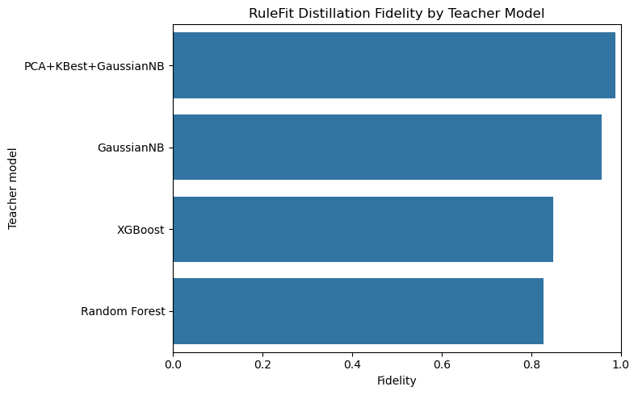

```python
# Plot the fidelity of the RuleFit surrogates for all teacher models
plt.figure(figsize=(8, 5))
sns.barplot(
    data=distillation_results_df.sort_values(by="fidelity", ascending=False),
    x="fidelity",
    y="teacher"
)
plt.title("RuleFit Distillation Fidelity by Teacher Model")
plt.xlabel("Fidelity")
plt.ylabel("Teacher model")
plt.xlim(0, 1)
plt.tight_layout()
plt.show()
```

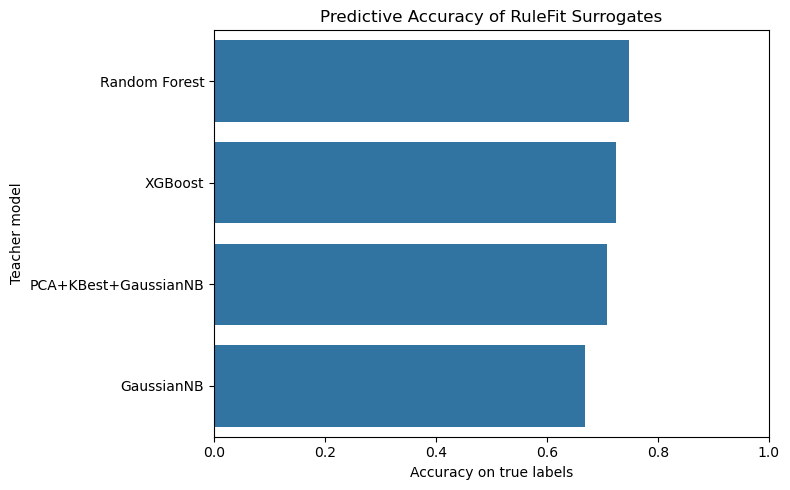

```python
# Plot the predictive accuracy of the RuleFit surrogates on the real test labels
plt.figure(figsize=(8, 5))
sns.barplot(
    data=distillation_results_df.sort_values(by="surrogate_accuracy", ascending=False),
    x="surrogate_accuracy",
    y="teacher"
)
plt.title("Predictive Accuracy of RuleFit Surrogates")
plt.xlabel("Accuracy on true labels")
plt.ylabel("Teacher model")
plt.xlim(0, 1)
plt.tight_layout()
plt.show()
```

```python
# Select one teacher model to inspect in more detail
selected_teacher = "XGBoost"

print(f"Detailed distilled rules for {selected_teacher}:")
display(surrogate_rules[selected_teacher][["rule", "coef", "support", "importance"]].head(15))
```

```
Detailed distilled rules for XGBoost:
```

|  | rule | coef | support | importance |
| --- | --- | --- | --- | --- |
| 47 | Job <= 2.5 and Housing_own <= 0.5 | 1.798882 | 0.224000 | 1.798882 |
| 26 | Age > 34.5 and Credit amount <= 8.92152 and Purpose_education <= 0.5 | -1.652161 | 0.373333 | 1.652161 |
| 48 | Check_no_inf <= 0.5 and Credit amount <= 7.2291 and Duration <= 34.5 | 1.523920 | 0.164000 | 1.523920 |
| 50 | Savings_no_inf <= 0.5 and Check_no_inf <= 0.5 and Duration > 22.5 | 1.390961 | 0.217333 | 1.390961 |
| 53 | Age <= 29.5 and Duration > 33.0 | 1.380671 | 0.062667 | 1.380671 |
| 45 | Check_no_inf <= 0.5 and Duration <= 31.5 and Purpose_car > 0.5 | 1.334775 | 0.177333 | 1.334775 |
| 39 | Check_no_inf <= 0.5 and Credit amount <= 8.2577 and Duration > 8.5 | 1.284034 | 0.384000 | 1.284034 |
| 31 | Credit amount <= 9.04274 and Duration <= 33.0 | -1.149859 | 0.805333 | 1.149859 |
| 46 | Age > 24.5 and Savings_no_inf <= 0.5 and Credit amount > 8.2531 | 1.008516 | 0.192000 | 1.008516 |
| 36 | Age > 33.5 and Check_no_inf <= 0.5 | 0.906009 | 0.270667 | 0.906009 |
| 30 | Credit amount <= 8.9568 and Duration <= 31.5 | -0.820466 | 0.793333 | 0.820466 |
| 24 | Check_no_inf <= 0.5 and Credit amount <= 8.2577 and Duration <= 8.5 | -0.755372 | 0.044000 | 0.755372 |
| 43 | Housing_own > 0.5 and Check_no_inf <= 0.5 and Credit amount > 8.2779 | 0.652229 | 0.101333 | 0.652229 |
| 54 | Age <= 28.5 and Check_no_inf <= 0.5 and Purpose_car > 0.5 | 0.575117 | 0.062667 | 0.575117 |
| 41 | Age <= 35.5 and Sex_male <= 0.5 and Housing_own > 0.5 | 0.428826 | 0.140000 | 0.428826 |